# Patrones Puntuales

# 4 Exploración espacial

Podemos ver en la Figura 4.1 que la distribución espacial de las estaciones de monitoreo no es homogénea, concentrándose principalmente en la zona urbana de Bogotá. Por otra parte, en el gif 4.2 se observa que, a lo largo del período de estudio, la mayoría de las estaciones presentan concentraciones de $PM_10$ dentro de rangos similares, evidenciado por la predominancia de colores y tamaños semejantes entre los puntos. Los episodios de concentraciones elevadas son poco frecuentes y se presentan únicamente en algunos instantes y estaciones específicas, lo que es consistente con la presencia de unos pocos valores extremos observados previamente en el diagrama de caja.

## 4.1 Mapa de bogotá

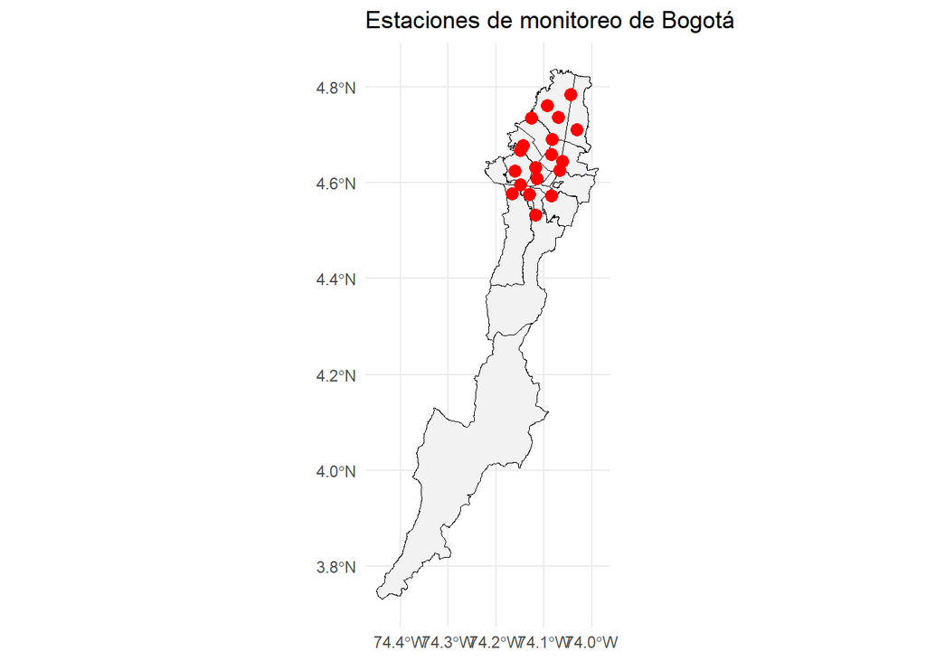

Figure 4.1: Visalización ed las 19 estaciones de Bogotá

```r
ggplot() +
  geom_sf(
    data = bogota,
    fill = "gray95",
    color = "black"
  ) +
  geom_sf(
    data = estaciones_sf,
    color = "red",
    size = 3
  ) +
  labs(
    title = "Estaciones de monitoreo de Bogotá"
  ) +
  theme_minimal()
```

## 4.2 Visualización con la variable

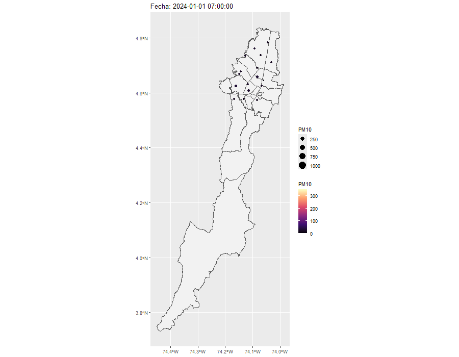

Figure 4.2: Gif de las observaciones a través del tiempo